# 重賞レース予測レポート【レース終了】

作成日時: 2026/04/05 16:21:58

☞ [マニュアル(pdf)](https://ryutoro-galois.github.io/keiba-predictor/manual/manual.pdf)

☞ 過去6年の同一レース結果: [2025年](https://ryutoro-galois.github.io/keiba-predictor/report/PredResult_2025y_raceDate_20250405_20250406.html), [2024年](https://ryutoro-galois.github.io/keiba-predictor/report/PredResult_2024y_raceDate_20240330_20240331.html), [2023年](https://ryutoro-galois.github.io/keiba-predictor/report/PredResult_2023y_raceDate_20230401_20230402.html), [2022年](https://ryutoro-galois.github.io/keiba-predictor/report/PredResult_2022y_raceDate_20220402_20220403.html), [2021年](https://ryutoro-galois.github.io/keiba-predictor/report/PredResult_2021y_raceDate_20210403_20210404.html), [2020年](https://ryutoro-galois.github.io/keiba-predictor/report/PredResult_2020y_raceDate_20200404_20200405.html)

☞ 過去4週間の別レース結果: [1週前(3/28-29)](https://ryutoro-galois.github.io/keiba-predictor/report/PredResult_2026y_raceDate_20260328_20260329.html), [2週前(3/21-22)](https://ryutoro-galois.github.io/keiba-predictor/report/PredResult_2026y_raceDate_20260321_20260322.html), [3週前(3/14-15)](https://ryutoro-galois.github.io/keiba-predictor/report/PredResult_2026y_raceDate_20260314_20260315.html), [4週前(3/7-8)](https://ryutoro-galois.github.io/keiba-predictor/report/PredResult_2026y_raceDate_20260307_20260308.html)

☞ netkeiba: [ダービー卿チャレンジ(GⅢ)](https://race.netkeiba.com/race/result.html?race_id=202606030311&rf=race_submenu), [チャーチルダウンズカップ(GⅢ)](https://race.netkeiba.com/race/result.html?race_id=202609020311&rf=race_submenu), [大阪杯(GⅠ)](https://race.netkeiba.com/race/result.html?race_id=202609020411&rf=race_submenu)

☞ レース結果(csv): [4/4-5](https://ryutoro-galois.github.io/keiba-predictor/csv/race_result_20260404_20260405.csv)

## 【レース結果(1)】人気と着順の関係

### 【ダービー卿チャレンジ(2026/04/04(土))】

【ダービー卿チャレンジ(GⅢ)】  
2026/04/04(土), 06_中山, 芝右外1600m

[interactive chart not shown]

### 【チャーチルダウンズカップ(2026/04/04(土))】

【チャーチルダウンズカップ(GⅢ)】  
2026/04/04(土), 09_阪神, 芝1600m

[interactive chart not shown]

### 【大阪杯(2026/04/05(日))】

【大阪杯(GⅠ)】  
2026/04/05(日), 09_阪神, 芝右2000m

[interactive chart not shown]

## 【レース結果(2)】コーナー通過順位

### 【ダービー卿チャレンジ(2026/04/04(土))】

【ダービー卿チャレンジ(GⅢ)】  
2026/04/04(土), 06_中山, 芝右外1600m

[interactive chart not shown]

### 【チャーチルダウンズカップ(2026/04/04(土))】

【チャーチルダウンズカップ(GⅢ)】  
2026/04/04(土), 09_阪神, 芝1600m

[interactive chart not shown]

### 【大阪杯(2026/04/05(日))】

【大阪杯(GⅠ)】  
2026/04/05(日), 09_阪神, 芝右2000m

[interactive chart not shown]

## 0. 推し馬予測 (AI予測)

### 【ダービー卿チャレンジ(GⅢ) 2026/04/04(土)】

- 本命(◎): 1-3着内確率(勝負強さ)が1位の馬
- 対抗(◯): 1-3着内確率が2-N位(20%程度以上)の中で予測タイムが最も速い馬
- 3番手(▲): 1-3着内確率が2-N位(20%程度以上)のでダークホース確率が最も高い馬
- 穴: ダークホース確率が上位1-M位(40%程度以上)の中で1-3着内確率が最も高い馬

| 推し馬 | 枠番 | 馬番 | 人気 | オッズ | 馬名 | 騎手 | 調教師 | 予測タイム(sec) | 1_順位 | 1-3着内確率(%) | 2_順位 | ﾀﾞｰｸﾎｰｽ確率(%) | 3_順位 |
| --- | --- | --- | --- | --- | --- | --- | --- | --- | --- | --- | --- | --- | --- |
| 本命(◎) | 1 | 2 | 2 | 6.0 | ミニトランザット | 西村淳也 | 杉山佳明 | 93.4 | 5 | 56.5 | 1 | 0.4 | 13 |
| 対抗(◯) | 8 | 15 | 5 | 9.1 | シリウスコルト | 三浦皇成 | 田中勝春 | 91.7 | 2 | 24.5 | 3 | 0.7 | 10 |
| 3番手(▲) | 5 | 10 | 3 | 6.8 | ケイアイセナ | 津村明秀 | 平田修 | 91.7 | 2 | 38.1 | 2 | 0.4 | 15 |
| 穴 | 2 | 3 | 11 | 16.7 | エンペラーズソード | 丹内祐次 | 高木登 | 101.8 | 13 | 8.3 | 9 | 22.9 | 2 |

### 【チャーチルダウンズカップ(GⅢ) 2026/04/04(土)】

- 本命(◎): 1-3着内確率(勝負強さ)が1位の馬
- 対抗(◯): 1-3着内確率が2-N位(20%程度以上)の中で予測タイムが最も速い馬
- 3番手(▲): 1-3着内確率が2-N位(20%程度以上)のでダークホース確率が最も高い馬
- 穴: ダークホース確率が上位1-M位(40%程度以上)の中で1-3着内確率が最も高い馬

| 推し馬 | 枠番 | 馬番 | 人気 | オッズ | 馬名 | 騎手 | 調教師 | 予測タイム(sec) | 1_順位 | 1-3着内確率(%) | 2_順位 | ﾀﾞｰｸﾎｰｽ確率(%) | 3_順位 |
| --- | --- | --- | --- | --- | --- | --- | --- | --- | --- | --- | --- | --- | --- |
| 本命(◎) | 6 | 10 | 3 | 6.9 | バルセシート | 北村友一 | 松下武士 | 100.3 | 6.0 | 44.7 | 1 | 0.4 | 12 |
| 対抗(◯) | 5 | 8 | 1 | 2.8 | アンドゥーリル | 川田将雅 | 中内田充正 | 93.7 | 1.5 | 22.8 | 3 | 0.4 | 13 |
| 3番手(▲) | 4 | 5 | 6 | 18.1 | シーミハットク | 高杉吏麒 | 寺島良 | 100.1 | 5.0 | 22.1 | 4 | 1.2 | 8 |
| 穴 | 1 | 1 | 12 | 75.7 | ストームサンダー | 斎藤新 | 安達昭夫 | 99.6 | 3.0 | 8.5 | 8 | 45.7 | 2 |

### 【大阪杯(GⅠ) 2026/04/05(日)】

- 本命(◎): 1-3着内確率(勝負強さ)が1位の馬
- 対抗(◯): 1-3着内確率が2-N位(20%程度以上)の中で予測タイムが最も速い馬
- 3番手(▲): 1-3着内確率が2-N位(20%程度以上)のでダークホース確率が最も高い馬
- 穴: ダークホース確率が上位1-M位(40%程度以上)の中で1-3着内確率が最も高い馬

| 推し馬 | 枠番 | 馬番 | 人気 | オッズ | 馬名 | 騎手 | 調教師 | 予測タイム(sec) | 1_順位 | 1-3着内確率(%) | 2_順位 | ﾀﾞｰｸﾎｰｽ確率(%) | 3_順位 |
| --- | --- | --- | --- | --- | --- | --- | --- | --- | --- | --- | --- | --- | --- |
| 本命(◎) | 8 | 15 | 1 | 2.8 | クロワデュノール | 北村友一 | 斉藤崇史 | 118.2 | 1.0 | 42.4 | 1 | 0.7 | 11 |
| 対抗(◯) | 3 | 4 | 2 | 4.3 | ダノンデサイル | 坂井瑠星 | 安田翔伍 | 119.0 | 2.0 | 20.6 | 7 | 0.5 | 13 |
| 3番手(▲) | 5 | 8 | 7 | 39.3 | エコロヴァルツ | 浜中俊 | 牧浦充徳 | 123.1 | 7.0 | 21.2 | 6 | 2.0 | 8 |
| 穴 | 7 | 13 | 12 | 65.4 | ファウストラーゼン | 岩田康誠 | 須貝尚介 | 125.4 | 13.5 | 13.0 | 8 | 46.3 | 2 |

## 1. 予測チャート (タイム/勝負強さ)

### 【ダービー卿チャレンジ(GⅢ)】

2026/04/04(土), 06_中山, 芝右外1600m

[interactive chart not shown]

### 【チャーチルダウンズカップ(GⅢ)】

2026/04/04(土), 09_阪神, 芝1600m

[interactive chart not shown]

### 【大阪杯(GⅠ)】

2026/04/05(日), 09_阪神, 芝右2000m

[interactive chart not shown]

## 2. オッズモニタリング (毎時)

### 【ダービー卿チャレンジ】

[interactive chart not shown]

### 【チャーチルダウンズカップ】

[interactive chart not shown]

### 【大阪杯】

[interactive chart not shown]

## 3. 出馬表

### 【ダービー卿チャレンジ 2026/04/04(土) 】

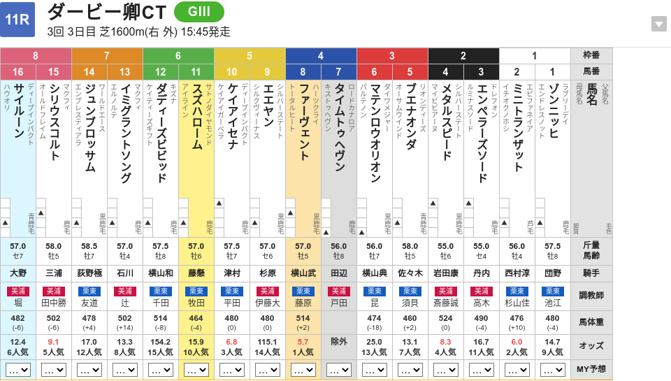

### 【チャーチルダウンズカップ 2026/04/04(土) 】

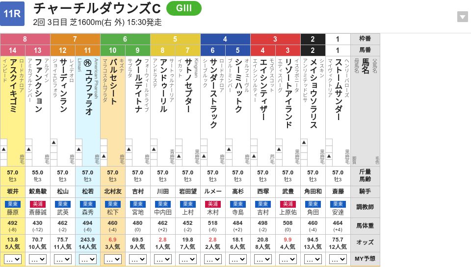

### 【大阪杯 2026/04/05(日) 】

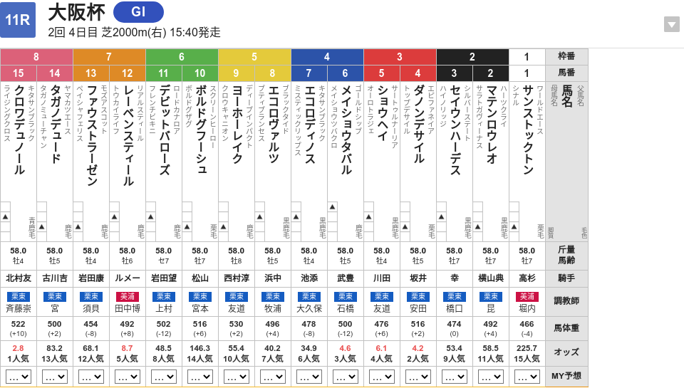

## 4. 単勝予測結果

### 【ダービー卿チャレンジ(GⅢ) 2026/04/04(土)】

| 枠番 | 馬番 | 人気 | オッズ | 馬名 | 騎手 | 調教師 | 予測タイム(sec) | 1_順位 | 1-3着内確率(%) | 2_順位 | ﾀﾞｰｸﾎｰｽ確率(%) | 3_順位 |
| --- | --- | --- | --- | --- | --- | --- | --- | --- | --- | --- | --- | --- |
| 1 | 1 | 9 | 14.7 | ゾンニッヒ | 団野大成 | 池江泰寿 | 99.8 | 9 | 6.2 | 11 | 11.1 | 7 |
| 1 | 2 | 2 | 6.0 | ミニトランザット | 西村淳也 | 杉山佳明 | 93.4 | 5 | 56.5 | 1 | 0.4 | 13 |
| 2 | 3 | 11 | 16.7 | エンペラーズソード | 丹内祐次 | 高木登 | 101.8 | 13 | 8.3 | 9 | 22.9 | 2 |
| 2 | 4 | 4 | 8.3 | メタルスピード | 岩田康誠 | 斎藤誠 | 103.0 | 15 | 14.4 | 6 | 0.6 | 12 |
| 3 | 5 | 7 | 13.1 | ブエナオンダ | 佐々木大輔 | 須貝尚介 | 97.2 | 6 | 12.7 | 7 | 1.1 | 8 |
| 3 | 6 | 13 | 25.0 | マテンロウオリオン | 横山典弘 | 昆貢 | 99.8 | 8 | 3.2 | 14 | 11.6 | 6 |
| 4 | 8 | 1 | 5.7 | ファーヴェント | 横山武史 | 藤原英昭 | 91.7 | 2 | 18.1 | 4 | 0.4 | 14 |
| 5 | 9 | 14 | 115.1 | エエヤン | 杉原誠人 | 伊藤大士 | 99.4 | 7 | 2.7 | 15 | 17.4 | 4 |
| 5 | 10 | 3 | 6.8 | ケイアイセナ | 津村明秀 | 平田修 | 91.7 | 2 | 38.1 | 2 | 0.4 | 15 |
| 6 | 11 | 10 | 15.9 | スズハローム | 藤懸貴志 | 牧田和弥 | 100.8 | 12 | 5.8 | 13 | 22.0 | 3 |

[output cut: 5 more lines]

### 【チャーチルダウンズカップ(GⅢ) 2026/04/04(土)】

| 枠番 | 馬番 | 人気 | オッズ | 馬名 | 騎手 | 調教師 | 予測タイム(sec) | 1_順位 | 1-3着内確率(%) | 2_順位 | ﾀﾞｰｸﾎｰｽ確率(%) | 3_順位 |
| --- | --- | --- | --- | --- | --- | --- | --- | --- | --- | --- | --- | --- |
| 1 | 1 | 12 | 75.7 | ストームサンダー | 斎藤新 | 安達昭夫 | 99.6 | 3.0 | 8.5 | 8 | 45.7 | 2 |
| 2 | 2 | 13 | 94.5 | メイショウソラリス | 角田大和 | 角田晃一 | 100.1 | 4.0 | 8.0 | 9 | 48.1 | 1 |
| 3 | 3 | 4 | 9.9 | リゾートアイランド | 武豊 | 上原佑紀 | 106.1 | 14.0 | 18.5 | 5 | 0.8 | 10 |
| 3 | 4 | 8 | 20.8 | エイシンティザー | 西塚洸二 | 吉村圭司 | 105.3 | 12.0 | 6.0 | 13 | 11.4 | 7 |
| 4 | 5 | 6 | 18.1 | シーミハットク | 高杉吏麒 | 寺島良 | 100.1 | 5.0 | 22.1 | 4 | 1.2 | 8 |
| 4 | 6 | 2 | 2.8 | サンダーストラック | Ｃ．ルメール | 木村哲也 | 93.7 | 1.5 | 9.7 | 7 | 0.3 | 14 |
| 5 | 7 | 7 | 19.8 | サトノセプター | 岩田望来 | 上村洋行 | 103.9 | 11.0 | 6.9 | 10 | 0.8 | 11 |
| 5 | 8 | 1 | 2.8 | アンドゥーリル | 川田将雅 | 中内田充正 | 93.7 | 1.5 | 22.8 | 3 | 0.4 | 13 |
| 6 | 9 | 9 | 69.5 | クールデイトナ | 吉村誠之助 | 宮地貴稔 | 106.1 | 13.0 | 2.4 | 14 | 11.8 | 6 |
| 6 | 10 | 3 | 6.9 | バルセシート | 北村友一 | 松下武士 | 100.3 | 6.0 | 44.7 | 1 | 0.4 | 12 |

[output cut: 4 more lines]

### 【大阪杯(GⅠ) 2026/04/05(日)】

| 枠番 | 馬番 | 人気 | オッズ | 馬名 | 騎手 | 調教師 | 予測タイム(sec) | 1_順位 | 1-3着内確率(%) | 2_順位 | ﾀﾞｰｸﾎｰｽ確率(%) | 3_順位 |
| --- | --- | --- | --- | --- | --- | --- | --- | --- | --- | --- | --- | --- |
| 1 | 1 | 15 | 222.0 | サンストックトン | 高杉吏麒 | 堀内岳志 | 125.3 | 12.0 | 5.6 | 13 | 30.9 | 6 |
| 2 | 2 | 11 | 58.6 | マテンロウレオ | 横山典弘 | 昆貢 | 125.2 | 10.0 | 5.4 | 14 | 27.7 | 7 |
| 2 | 3 | 9 | 52.3 | セイウンハーデス | 幸英明 | 橋口慎介 | 127.5 | 15.0 | 4.9 | 15 | 32.8 | 5 |
| 3 | 4 | 2 | 4.3 | ダノンデサイル | 坂井瑠星 | 安田翔伍 | 119.0 | 2.0 | 20.6 | 7 | 0.5 | 13 |
| 3 | 5 | 4 | 6.2 | ショウヘイ | 川田将雅 | 友道康夫 | 125.4 | 13.5 | 25.6 | 4 | 0.5 | 15 |
| 4 | 6 | 3 | 4.5 | メイショウタバル | 武豊 | 石橋守 | 122.4 | 4.0 | 21.5 | 5 | 0.5 | 14 |
| 4 | 7 | 6 | 34.5 | エコロディノス | 池添謙一 | 大久保龍志 | 124.1 | 8.0 | 35.3 | 2 | 1.6 | 9 |
| 5 | 8 | 7 | 39.3 | エコロヴァルツ | 浜中俊 | 牧浦充徳 | 123.1 | 7.0 | 21.2 | 6 | 2.0 | 8 |
| 5 | 9 | 10 | 54.7 | ヨーホーレイク | 西村淳也 | 友道康夫 | 125.2 | 10.0 | 9.2 | 9 | 35.0 | 4 |
| 6 | 10 | 14 | 145.5 | ボルドグフーシュ | 松山弘平 | 宮本博 | 125.2 | 10.0 | 9.0 | 10 | 56.3 | 1 |

[output cut: 5 more lines]

## 5. 人気と着順の乖離率推移

### 【ダービー卿チャレンジ_1990y_2019y】

[interactive chart not shown]

### 【大阪杯_1990y_2019y】

[interactive chart not shown]

### 【ダービー卿チャレンジ_1990y_2019y】

| No | 開催年 | 不整合率(%) | 頭数 | 人気別着順(1-3位) | 人気別着順(全体) |
| --- | --- | --- | --- | --- | --- |
| 30 | 2019 | 41.0 | 16頭 | 2-3-7 | 2\|3\|7\|5\|4\|6\|1\|10\|8\|15\|9\|14\|12\|11\|16\|13 |
| 29 | 2018 | 38.7 | 16頭 | 4-6-9 | 4\|6\|9\|5\|1\|7\|2\|14\|3\|8\|15\|12\|16\|11\|13\|10 |
| 28 | 2017 | 18.7 | 16頭 | 5-1-2 | 5\|1\|2\|3\|8\|7\|12\|4\|6\|10\|15\|16\|11\|13\|14\|9 |
| 27 | 2016 | 57.4 | 16頭 | 5-4-2 | 5\|4\|2\|7\|6\|3\|8\|1\|13\|9\|15\|10\|16\|11\|12\|14 |
| 26 | 2015 | 44.7 | 16頭 | 1-4-9 | 1\|4\|9\|5\|7\|11\|14\|10\|8\|13\|6\|3\|16\|2\|15\|12 |
| 25 | 2014 | 43.0 | 16頭 | 4-9-8 | 4\|9\|8\|12\|1\|13\|7\|14\|5\|15\|11\|10\|16\|2\|6\|3 |
| 24 | 2013 | 26.6 | 16頭 | 5-1-2 | 5\|1\|2\|14\|6\|8\|11\|15\|4\|3\|10\|7\|9\|13\|16\|12 |
| 23 | 2012 | 43.6 | 16頭 | 3-10-7 | 3\|10\|7\|8\|1\|2\|9\|12\|15\|11\|13\|6\|4\|14\|5\|16 |
| 22 | 2011 | 50.6 | 18頭 | 8-2-6 | 8\|2\|6\|7\|12\|3\|10\|4\|5\|9\|18\|14\|1\|13\|15\|16\|11\|17 |
| 21 | 2010 | 51.5 | 16頭 | 7-4-5 | 7\|4\|5\|2\|6\|8\|9\|13\|15\|1\|12\|14\|16\|11\|10\|3 |

[output cut: 20 more lines]

### 【大阪杯_1990y_2019y】

| No | 開催年 | 不整合率(%) | 頭数 | 人気別着順(1-3位) | 人気別着順(全体) |
| --- | --- | --- | --- | --- | --- |
| 30 | 2019 | 41.2 | 14頭 | 9-2-4 | 9\|2\|4\|10\|5\|1\|13\|14\|11\|8\|3\|7\|12\|6 |
| 29 | 2018 | 21.2 | 16頭 | 1-6-2 | 1\|6\|2\|10\|5\|8\|3\|7\|11\|14\|15\|9\|4\|16\|13\|12 |
| 28 | 2017 | 21.7 | 14頭 | 1-7-4 | 1\|7\|4\|2\|5\|3\|6\|11\|14\|13\|12\|8\|9\|10 |
| 27 | 2016 | 38.7 | 11頭 | 2-5-4 | 2\|5\|4\|1\|7\|3\|8\|10\|6\|9\|11 |
| 26 | 2015 | 25.3 | 14頭 | 4-1-6 | 4\|1\|6\|2\|3\|8\|12\|5\|7\|14\|13\|10\|11\|9 |
| 25 | 2014 | 38.0 | 8頭 | 2-6-1 | 2\|6\|1\|5\|4\|8\|3\|7 |
| 24 | 2013 | 12.1 | 14頭 | 1-2-5 | 1\|2\|5\|6\|3\|4\|9\|7\|12\|11\|13\|8\|10\|14 |
| 23 | 2012 | 16.5 | 12頭 | 6-1-2 | 6\|1\|2\|4\|3\|5\|7\|9\|11\|10\|8\|12 |
| 22 | 2011 | 28.5 | 15頭 | 1-8-3 | 1\|8\|3\|5\|2\|9\|7\|6\|10\|4\|15\|11\|13\|12\|14 |
| 21 | 2010 | 33.6 | 12頭 | 6-9-1 | 6\|9\|1\|12\|5\|7\|2\|4\|8\|3\|11\|10 |

[output cut: 20 more lines]

## 6. 1-3番人気馬の着順分類予測

### 【ダービー卿チャレンジ】

| 分類 | 凡例 | 発生確率(%) | 当該レース | 当該レースランク | 直近1年間 |
| --- | --- | --- | --- | --- | --- |
| 4: 1,2番人気のみ (4_pop12) | 1 \| 2 \| * | 17.8 | 1.28 | 1.28 | 0.00 |
| 1: 1番人気のみ (1_pop1) | 1 \| * \| * | 17.4 | 1.57 | 1.57 | 0.00 |
| 8: 1,2,3番人気すべて着外 (8_darkhorse) | * \| * \| * | 13.9 | 0.83 | 0.83 | 0.00 |
| 6: 2,3番人気のみ (6_pop23) | 2 \| 3 \| * | 13.5 | 0.49 | 0.49 | 0.27 |
| 5: 1,3番人気のみ (5_pop13) | 1 \| 3 \| * | 13.1 | 2.34 | 2.34 | 0.00 |
| 2: 2番人気のみ (2_pop2) | 2 \| * \| * | 9.0 | 0.65 | 0.65 | 0.18 |
| 3: 3番人気のみ (3_pop3) | 3 \| * \| * | 8.3 | 1.48 | 1.48 | 0.00 |
| 7: 1,2,3番人気すべて着内 (7_pop123) | 1 \| 2 \| 3 | 7.0 | 1.25 | 1.25 | 0.00 |

### 【大阪杯】

| 分類 | 凡例 | 発生確率(%) | 当該レース | 当該レースランク | 直近1年間 |
| --- | --- | --- | --- | --- | --- |
| 4: 1,2番人気のみ (4_pop12) | 1 \| 2 \| * | 17.8 | 0.92 | 1.60 | 0.00 |
| 1: 1番人気のみ (1_pop1) | 1 \| * \| * | 17.4 | 0.90 | 1.57 | 0.00 |
| 8: 1,2,3番人気すべて着外 (8_darkhorse) | * \| * \| * | 13.9 | 1.25 | 0.00 | 0.00 |
| 6: 2,3番人気のみ (6_pop23) | 2 \| 3 \| * | 13.5 | 0.00 | 0.00 | 0.00 |
| 5: 1,3番人気のみ (5_pop13) | 1 \| 3 \| * | 13.1 | 0.94 | 0.00 | 0.00 |
| 2: 2番人気のみ (2_pop2) | 2 \| * \| * | 9.0 | 0.41 | 0.12 | 0.09 |
| 3: 3番人気のみ (3_pop3) | 3 \| * \| * | 8.3 | 1.48 | 0.00 | 0.00 |
| 7: 1,2,3番人気すべて着内 (7_pop123) | 1 \| 2 \| 3 | 7.0 | 0.84 | 0.00 | 0.00 |

## 7. 3連複予測結果

### 【ダービー卿チャレンジ(GⅢ) 2026/04/04(土)】

| 分類 | 馬番 | 枠番 | 人気 | 平均予測タイム(sec) | 1-3着内確率(%) | ﾀﾞｰｸﾎｰｽ確率(%) | 馬名 | 騎手 | 調教師 |
| --- | --- | --- | --- | --- | --- | --- | --- | --- | --- |
| 6: 2,3番人気のみ (6_pop23) | 2-10-15 | 1-5-8 | 2-3-5 | 92.27 | 5.27 | 0.00 | ミニトランザット \| ケイアイセナ \| シリウスコルト | 西村淳也 \| 津村明秀 \| 三浦皇成 | 杉山佳明 \| 平田修 \| 田中勝春 |
| 7: 1,2,3番人気すべて着内 (7_pop123) | 8-2-10 | 4-1-5 | 1-2-3 | 92.27 | 3.90 | 0.00 | ファーヴェント \| ミニトランザット \| ケイアイセナ | 横山武史 \| 西村淳也 \| 津村明秀 | 藤原英昭 \| 杉山佳明 \| 平田修 |
| 6: 2,3番人気のみ (6_pop23) | 2-10-13 | 1-5-7 | 2-3-8 | 92.60 | 3.17 | 0.00 | ミニトランザット \| ケイアイセナ \| イミグラントソング | 西村淳也 \| 津村明秀 \| 石川裕紀人 | 杉山佳明 \| 平田修 \| 辻哲英 |
| 6: 2,3番人気のみ (6_pop23) | 2-10-4 | 1-5-2 | 2-3-4 | 96.03 | 3.10 | 0.00 | ミニトランザット \| ケイアイセナ \| メタルスピード | 西村淳也 \| 津村明秀 \| 岩田康誠 | 杉山佳明 \| 平田修 \| 斎藤誠 |
| 6: 2,3番人気のみ (6_pop23) | 2-10-5 | 1-5-3 | 2-3-7 | 94.10 | 2.74 | 0.00 | ミニトランザット \| ケイアイセナ \| ブエナオンダ | 西村淳也 \| 津村明秀 \| 佐々木大輔 | 杉山佳明 \| 平田修 \| 須貝尚介 |
| 4: 1,2番人気のみ (4_pop12) | 8-2-15 | 4-1-8 | 1-2-5 | 92.27 | 2.51 | 0.00 | ファーヴェント \| ミニトランザット \| シリウスコルト | 横山武史 \| 西村淳也 \| 三浦皇成 | 藤原英昭 \| 杉山佳明 \| 田中勝春 |
| 6: 2,3番人気のみ (6_pop23) | 2-10-16 | 1-5-8 | 2-3-6 | 95.00 | 2.17 | 0.00 | ミニトランザット \| ケイアイセナ \| サイルーン | 西村淳也 \| 津村明秀 \| 大野拓弥 | 杉山佳明 \| 平田修 \| 堀宣行 |
| 2: 2番人気のみ (2_pop2) | 2-15-13 | 1-8-7 | 2-5-8 | 92.60 | 2.03 | 0.00 | ミニトランザット \| シリウスコルト \| イミグラントソング | 西村淳也 \| 三浦皇成 \| 石川裕紀人 | 杉山佳明 \| 田中勝春 \| 辻哲英 |
| 2: 2番人気のみ (2_pop2) | 2-4-15 | 1-2-8 | 2-4-5 | 96.03 | 1.99 | 0.00 | ミニトランザット \| メタルスピード \| シリウスコルト | 西村淳也 \| 岩田康誠 \| 三浦皇成 | 杉山佳明 \| 斎藤誠 \| 田中勝春 |
| 6: 2,3番人気のみ (6_pop23) | 2-10-3 | 1-5-2 | 2-3-11 | 95.63 | 1.79 | 0.00 | ミニトランザット \| ケイアイセナ \| エンペラーズソード | 西村淳也 \| 津村明秀 \| 丹内祐次 | 杉山佳明 \| 平田修 \| 高木登 |

[output cut: 445 more lines]

### 【チャーチルダウンズカップ(GⅢ) 2026/04/04(土)】

| 分類 | 馬番 | 枠番 | 人気 | 平均予測タイム(sec) | 1-3着内確率(%) | ﾀﾞｰｸﾎｰｽ確率(%) | 馬名 | 騎手 | 調教師 |
| --- | --- | --- | --- | --- | --- | --- | --- | --- | --- |
| 5: 1,3番人気のみ (5_pop13) | 8-10-14 | 5-6-8 | 1-3-5 | 98.23 | 2.52 | 0.00 | アンドゥーリル \| バルセシート \| アスクイキゴミ | 川田将雅 \| 北村友一 \| 坂井瑠星 | 中内田充正 \| 松下武士 \| 藤原英昭 |
| 3: 3番人気のみ (3_pop3) | 10-14-5 | 6-8-4 | 3-5-6 | 100.37 | 2.45 | 0.00 | バルセシート \| アスクイキゴミ \| シーミハットク | 北村友一 \| 坂井瑠星 \| 高杉吏麒 | 松下武士 \| 藤原英昭 \| 寺島良 |
| 5: 1,3番人気のみ (5_pop13) | 8-10-5 | 5-6-4 | 1-3-6 | 98.03 | 2.25 | 0.00 | アンドゥーリル \| バルセシート \| シーミハットク | 川田将雅 \| 北村友一 \| 高杉吏麒 | 中内田充正 \| 松下武士 \| 寺島良 |
| 3: 3番人気のみ (3_pop3) | 10-3-14 | 6-3-8 | 3-4-5 | 102.37 | 2.05 | 0.00 | バルセシート \| リゾートアイランド \| アスクイキゴミ | 北村友一 \| 武豊 \| 坂井瑠星 | 松下武士 \| 上原佑紀 \| 藤原英昭 |
| 5: 1,3番人気のみ (5_pop13) | 8-10-3 | 5-6-3 | 1-3-4 | 100.03 | 1.88 | 0.00 | アンドゥーリル \| バルセシート \| リゾートアイランド | 川田将雅 \| 北村友一 \| 武豊 | 中内田充正 \| 松下武士 \| 上原佑紀 |
| 3: 3番人気のみ (3_pop3) | 10-3-5 | 6-3-4 | 3-4-6 | 102.17 | 1.83 | 0.00 | バルセシート \| リゾートアイランド \| シーミハットク | 北村友一 \| 武豊 \| 高杉吏麒 | 松下武士 \| 上原佑紀 \| 寺島良 |
| 1: 1番人気のみ (1_pop1) | 8-14-5 | 5-8-4 | 1-5-6 | 98.17 | 1.25 | 0.00 | アンドゥーリル \| アスクイキゴミ \| シーミハットク | 川田将雅 \| 坂井瑠星 \| 高杉吏麒 | 中内田充正 \| 藤原英昭 \| 寺島良 |
| 3: 3番人気のみ (3_pop3) | 10-14-13 | 6-8-8 | 3-5-10 | 100.63 | 1.13 | 0.00 | バルセシート \| アスクイキゴミ \| ファンクション | 北村友一 \| 坂井瑠星 \| 鮫島克駿 | 松下武士 \| 藤原英昭 \| 斎藤誠 |
| 6: 2,3番人気のみ (6_pop23) | 6-10-14 | 4-6-8 | 2-3-5 | 98.23 | 1.08 | 0.00 | サンダーストラック \| バルセシート \| アスクイキゴミ | Ｃ．ルメール \| 北村友一 \| 坂井瑠星 | 木村哲也 \| 松下武士 \| 藤原英昭 |
| 1: 1番人気のみ (1_pop1) | 8-3-14 | 5-3-8 | 1-4-5 | 100.17 | 1.04 | 0.00 | アンドゥーリル \| リゾートアイランド \| アスクイキゴミ | 川田将雅 \| 武豊 \| 坂井瑠星 | 中内田充正 \| 上原佑紀 \| 藤原英昭 |

[output cut: 354 more lines]

### 【大阪杯(GⅠ) 2026/04/05(日)】

| 分類 | 馬番 | 枠番 | 人気 | 平均予測タイム(sec) | 1-3着内確率(%) | ﾀﾞｰｸﾎｰｽ確率(%) | 馬名 | 騎手 | 調教師 |
| --- | --- | --- | --- | --- | --- | --- | --- | --- | --- |
| 1: 1番人気のみ (1_pop1) | 15-12-7 | 8-7-4 | 1-5-6 | 120.93 | 4.99 | 0.00 | クロワデュノール \| レーベンスティール \| エコロディノス | 北村友一 \| Ｃ．ルメール \| 池添謙一 | 斉藤崇史 \| 田中博康 \| 大久保龍志 |
| 1: 1番人気のみ (1_pop1) | 15-5-7 | 8-3-4 | 1-4-6 | 122.57 | 3.83 | 0.00 | クロワデュノール \| ショウヘイ \| エコロディノス | 北村友一 \| 川田将雅 \| 池添謙一 | 斉藤崇史 \| 友道康夫 \| 大久保龍志 |
| 1: 1番人気のみ (1_pop1) | 15-5-12 | 8-3-7 | 1-4-5 | 121.37 | 3.62 | 0.00 | クロワデュノール \| ショウヘイ \| レーベンスティール | 北村友一 \| 川田将雅 \| Ｃ．ルメール | 斉藤崇史 \| 友道康夫 \| 田中博康 |
| 5: 1,3番人気のみ (5_pop13) | 15-6-7 | 8-4-4 | 1-3-6 | 121.57 | 3.22 | 0.00 | クロワデュノール \| メイショウタバル \| エコロディノス | 北村友一 \| 武豊 \| 池添謙一 | 斉藤崇史 \| 石橋守 \| 大久保龍志 |
| 1: 1番人気のみ (1_pop1) | 15-7-8 | 8-4-5 | 1-6-7 | 121.80 | 3.17 | 0.00 | クロワデュノール \| エコロディノス \| エコロヴァルツ | 北村友一 \| 池添謙一 \| 浜中俊 | 斉藤崇史 \| 大久保龍志 \| 牧浦充徳 |
| 4: 1,2番人気のみ (4_pop12) | 15-4-7 | 8-3-4 | 1-2-6 | 120.43 | 3.08 | 0.00 | クロワデュノール \| ダノンデサイル \| エコロディノス | 北村友一 \| 坂井瑠星 \| 池添謙一 | 斉藤崇史 \| 安田翔伍 \| 大久保龍志 |
| 5: 1,3番人気のみ (5_pop13) | 15-6-12 | 8-4-7 | 1-3-5 | 120.37 | 3.04 | 0.00 | クロワデュノール \| メイショウタバル \| レーベンスティール | 北村友一 \| 武豊 \| Ｃ．ルメール | 斉藤崇史 \| 石橋守 \| 田中博康 |
| 8: 1,2,3番人気すべて着外 (8_darkhorse) | 5-12-7 | 3-7-4 | 4-5-6 | 123.33 | 3.02 | 0.00 | ショウヘイ \| レーベンスティール \| エコロディノス | 川田将雅 \| Ｃ．ルメール \| 池添謙一 | 友道康夫 \| 田中博康 \| 大久保龍志 |
| 1: 1番人気のみ (1_pop1) | 15-12-8 | 8-7-5 | 1-5-7 | 120.60 | 2.99 | 0.00 | クロワデュノール \| レーベンスティール \| エコロヴァルツ | 北村友一 \| Ｃ．ルメール \| 浜中俊 | 斉藤崇史 \| 田中博康 \| 牧浦充徳 |
| 4: 1,2番人気のみ (4_pop12) | 15-4-12 | 8-3-7 | 1-2-5 | 119.23 | 2.91 | 0.00 | クロワデュノール \| ダノンデサイル \| レーベンスティール | 北村友一 \| 坂井瑠星 \| Ｃ．ルメール | 斉藤崇史 \| 安田翔伍 \| 田中博康 |

[output cut: 445 more lines]

## 8. 直近の全レース情報

[output not shown]

[output cut: 3 more lines]